# Project Blog

Nicholas Perry

29 April, 2019

# Introduction

This is my Project Blog. This is all of the code that I currently have working, as well as the figures that I have made.

# Preliminary Step

```bash
cat Eco8_48hr_reads.fasta Eco8_4x8hr_reads.fasta > Eco8.fasta
```

By using cat, I was able to put all of the Eco8 fasta files into a single fasta file so that canu could be run more easily.

# Canu

```bash
canu -p snake_venom -d snake_venom genomeSize=1m maxThreads=8 -nanopore-raw /home/nperry/nperry/snake_venom/Eco6_4x8hr.fasta > canuLogFile

canu -p Eco8_snake_venom -d Eco8_snake_venom genomeSize=1m maxThreads=8 -nanopore-raw /home/nperry/nperry/snake_venom/Eco8.fasta > canuLogFile2
```

By using canu, I was able to assemble contigs for the Eco6_4x8 reads and the Eco8 reads.

# Setup Directory and Variables

```bash
cd /home/nperry/nperry/snake_venom/snake_venom

datapath=/home/nperry/nperry/snake_venom/

reads1=$datapath/Eco6_4x8hr.fasta

reads2=$datapath/Eco8.fasta

assembly1=$datapath/snake_venom/snake_venom.contigs.fasta

assembly2=$datapath/Eco8_snake_venom/Eco8_snake_venom.contigs.fasta
```

This is the directory that I worked in, as well as variables that I set so I did not have to type the directory in every time.

# Nanopore Polishing Pilon

```bash
cp $assembly1 ./

aslocal1=snake_venom.contigs.fasta

bwa index $aslocal1

bwa mem -t 4 $aslocal1 $reads1 | samtools view - -Sb | samtools sort - -@4 -o WGS.sorted.bam

samtools index WGS.sorted.bam

wget https://github.com/broadinstitute/pilon/releases/download/v1.23/pilon-1.23.jar

java -Xmx64G -jar pilon-1.23.jar --genome $aslocal1 --fix all --changes --bam WGS.sorted.bam --threads 4 --outdir pilonpolish

ls -lh pilonpolish

aslocal2=Eco8_snake_venom.contigs.fasta

bwa index $aslocal2

bwa mem -t 4 $aslocal2 $reads2 | samtools view - -Sb | samtools sort - -@4 -o WGS1.sorted.bam

samtools index WGS1.sorted.bam

wget https://github.com/broadinstitute/pilon/releases/download/v1.23/pilon-1.23.jar

java -Xmx64G -jar pilon-1.23.jar --genome $aslocal2 --fix all --changes --bam WGS1.sorted.bam --threads 4 --outdir pilonpolish

ls -lh pilonpolish
```

Using Pilon, I was able to polish the genomes of the Eco6_4x8 reads and the Eco8 reads using the Nanopore data.

# Illumina Polishing Pilon

```bash
reads=$datapath/SRR1287715.fastq

cp $assembly2 ./

aslocal=Eco8_snake_venom.contigs.fasta

bwa index $aslocal

bwa mem -t 4 $aslocal $reads | samtools view - -Sb | samtools sort - -@4 -o WGS.sorted.bam

samtools index WGS.sorted.bam

wget https://github.com/broadinstitute/pilon/releases/download/v1.23/pilon-1.23.jar

java -Xmx64G -jar pilon-1.23.jar --genome $aslocal --fix all --changes --bam WGS.sorted.bam --threads 4 --outdir pilonpolishillumina

ls -lh

cp $assembly1 ./

aslocal=snake_venom.contigs.fasta

bwa index $aslocal

bwa mem -t 4 $aslocal $reads | samtools view - -Sb | samtools sort - -@4 -o WGS.sorted.bam

samtools index WGS.sorted.bam

wget https://github.com/broadinstitute/pilon/releases/download/v1.23/pilon-1.23.jar

java -Xmx64G -jar pilon-1.23.jar --genome $aslocal --fix all --changes --bam WGS.sorted.bam --threads 4 --outdir pilonpolishillumina

ls -lh
```

Using Pilon, I was able to polish the genomes of the Eco6_4x8 reads and the Eco8 reads using the Illumina data.

# Gene Prediction from Original Assembly

```bash
prodigal.linux -i /home/nperry/nperry/snake_venom/snake_venom/snake_venom.contigs.fasta -o prodigal.test -a proteins.faa
```

I am using this to predict the genes from the original assembly. The figure shows which of the predicted proteins had the highest counts.

```r
getwd()
```

```
## [1] "/home/nperry/nperry"
```

```r
setwd("/home/nperry/b2gWorkspace")
library(plyr)
library(ggplot2)
library(forcats)
proteins <- read.delim("blast2go_go_table.txt", header=TRUE, stringsAsFactors = FALSE)
proteins_split <- strsplit(proteins$GO.Names, ";")
unlist_proteins_split <- unlist(proteins_split)
gocounts <- count(unlist(proteins_split))
gocounts[order(gocounts$freq, decreasing = TRUE),]
```

|  | x | freq |
| --- | --- | --- |
| 68 | F:toxin activity | 15 |
| 117 | P:pathogenesis | 15 |
| 133 | P:proteolysis | 15 |
| 163 | F:metalloendopeptidase activity | 10 |
| 53 | F:metallopeptidase activity | 8 |
| 12 | C:extracellular region | 7 |
| 51 | F:metal ion binding | 6 |
| 166 | F:nucleotide binding | 6 |
| 14 | C:integral component of membrane | 5 |
| 16 | C:membrane | 5 |

[output cut: 167 more lines]

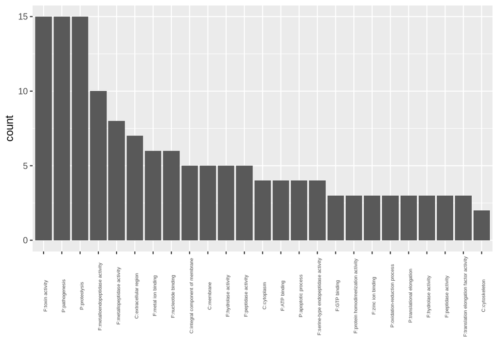

```r
counts <- gocounts[order(gocounts$freq, decreasing = TRUE),]
tophits = counts[1:25, 'x']
topproteins <- as.data.frame(unlist_proteins_split[unlist_proteins_split %in% tophits])
colnames(topproteins)=c("GoNames")
ggplot(data=topproteins) +
    geom_bar(aes(x=fct_infreq(GoNames))) +
    xlab('') +
    theme(axis.text.x  = element_text(angle=90, size = 5))
```

# Transrate

```bash
transrate --assembly snake_venom.contigs.fasta

cd pilonpolishillumina/

transrate --assembly pilon.fasta

cd pilonpolish

transrate --assembly pilon.fasta
```

I ran Transrate on the snake_venom_contigs file, along with each of the polished files for Eco6_4x8. I have not done this for the Eco8 file yet. Transrate assesses the quality of the assembly.

# NanoStat

```bash
NanoStat --fasta Eco6_4x8hr_reads.fasta > ns.file
```

I ran NanoStat on on my Eco6 reads so that I could get summary data on the reads. I have not done this for the Eco8 data yet.

# Preliminary Figure Information

```bash
awk '/^>/ {if (seqlen){print seqlen}; printf $0" " ;seqlen=0;next; } { seqlen += length($0)}END{print seqlen}' Eco6_4x8hr_reads.fasta > readlength2.file
awk '/^>/ {if (seqlen){print seqlen}; printf $0" " ;seqlen=0;next; } { seqlen += length($0)}END{print seqlen}' Eco6_48hr_reads.fasta > readlength3.file
awk '/^>/ {if (seqlen){print seqlen}; printf $0" " ;seqlen=0;next; } { seqlen += length($0)}END{print seqlen}' Eco8_48hr_reads.fasta > readlength4.file
awk '/^>/ {if (seqlen){print seqlen}; printf $0" " ;seqlen=0;next; } { seqlen += length($0)}END{print seqlen}' Eco8_4x8hr_reads.fasta > readlength5.file
```

I used the awk command to get all of the read lengths into a file that I could read into R. In R, I would be able to make read distribution graphs for each of the 4 samples.

# Read Length Distribution Figures

```r
library(ggplot2)
getwd()
```

```
## [1] "/home/nperry/nperry"
```

```r
setwd("/home/nperry/nperry/snake_venom/")
eco6_4x8<-read.delim("readlength2.file", header=FALSE, sep=" ", stringsAsFactors = FALSE)
eco6_4x8$V2=as.numeric(eco6_4x8$V2)
```

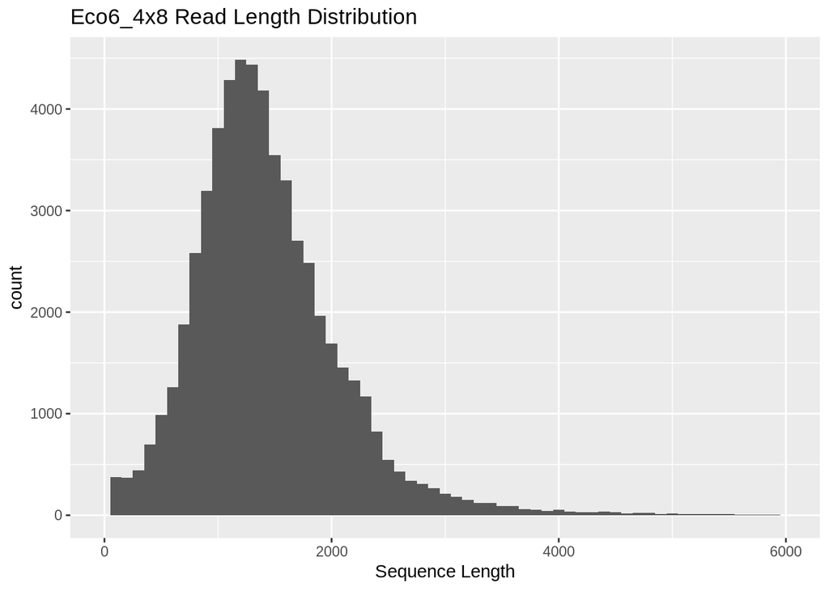

```r
ggplot(data=eco6_4x8) + geom_histogram(aes(x=eco6_4x8$V2), binwidth=100) + xlim(0,6000)+xlab("Sequence Length")+ggtitle("Eco6_4x8 Read Length Distribution")
```

This is the read distribution for Eco6_4x8, which had a lot of reads around 2000 base pairs.

```r
library(ggplot2)
getwd()
```

```
## [1] "/home/nperry/nperry"
```

```r
setwd("/home/nperry/nperry/snake_venom/")
eco6_48<-read.delim("readlength3.file", header=FALSE, sep=" ", stringsAsFactors = FALSE)
eco6_48$V2=as.numeric(eco6_48$V2)
```

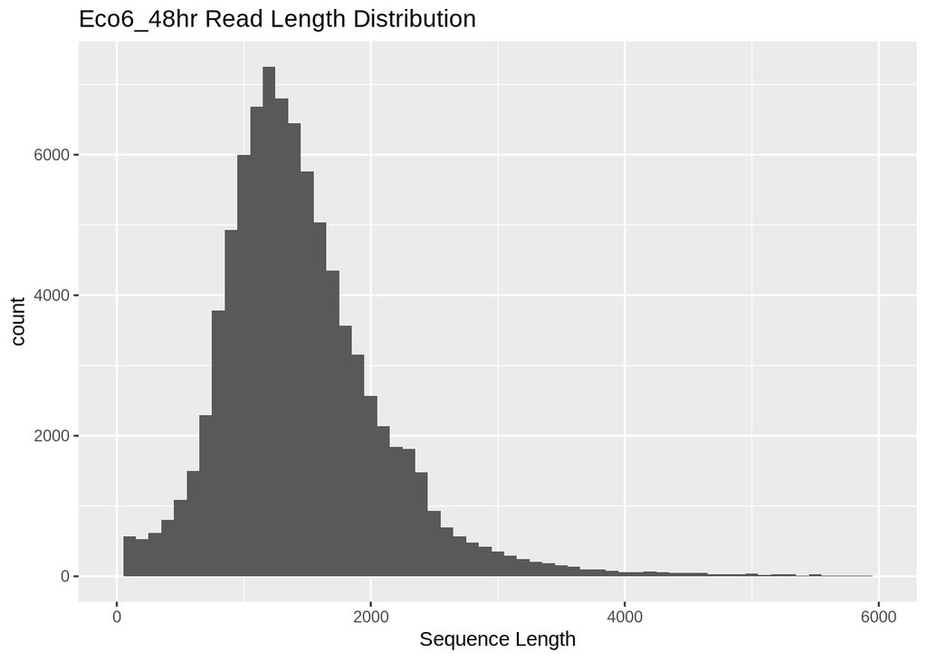

```r
ggplot(data=eco6_48) + geom_histogram(aes(x=eco6_48$V2), binwidth=100) + xlim(0,6000)+xlab("Sequence Length")+ggtitle("Eco6_48hr Read Length Distribution")
```

```r
library(ggplot2)
getwd()
```

```
## [1] "/home/nperry/nperry"
```

```r
setwd("/home/nperry/nperry/snake_venom/")
eco8_48<-read.delim("readlength4.file", header=FALSE, sep=" ", stringsAsFactors = FALSE)
eco8_48$V2=as.numeric(eco8_48$V2)
```

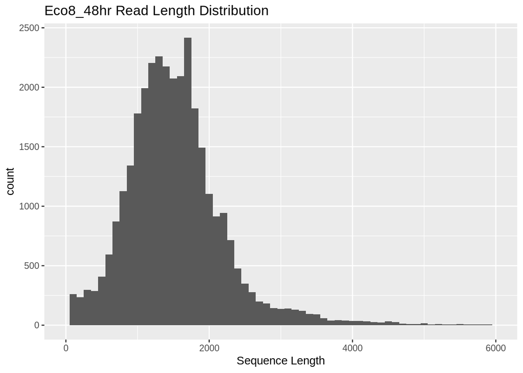

```r
ggplot(data=eco8_48) + geom_histogram(aes(x=eco8_48$V2), binwidth=100) + xlim(0,6000)+xlab("Sequence Length")+ggtitle("Eco8_48hr Read Length Distribution")
```

This is the read distribution for Eco8_48hr, which had the lowest number of reads around 2000 base pairs. Since it did not have a high number of reads, it was combined with the Eco8_4x8 reads.

```r
library(ggplot2)
getwd()
```

```
## [1] "/home/nperry/nperry"
```

```r
setwd("/home/nperry/nperry/snake_venom/")








eco8_4x8<-read.delim("readlength5.file", header=FALSE, sep=" ", stringsAsFactors = FALSE)
eco8_4x8$V2=as.numeric(eco8_4x8$V2)
```

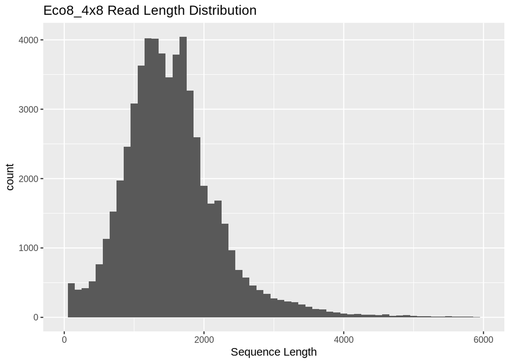

```r
ggplot(data=eco8_4x8) + geom_histogram(aes(x=eco8_4x8$V2), binwidth=100) + xlim(0,6000)+xlab("Sequence Length")+ggtitle("Eco8_4x8 Read Length Distribution")
```